# Nadya_scotty-cl-cov

Nadya

27/10/2020

```r
library(tidyverse)
library(lubridate)
scotty_train <- read_csv("data/data-train.csv")
glimpse(scotty_train)
```

```
## Rows: 229,532
## Columns: 16
## $ id                 <chr> "59d005e1ffcfa261708ce9cd", "59d0066a3d32b861760...
## $ trip_id            <chr> "59d005e9cb564761a8fe5d3e", "59d00678ffcfa261708...
## $ driver_id          <chr> "59a892c5568be44b2734f276", "59a135565e88a24b11f...
## $ rider_id           <chr> "59ad2d6efba75a581666b506", "59ce930f3d32b861760...
## $ start_time         <dttm> 2017-10-01 00:00:17, 2017-10-01 00:02:34, 2017-...
## $ src_lat            <dbl> 41.07047, 40.94157, 41.07487, 41.04995, 41.05287...
## $ src_lon            <dbl> 29.01945, 29.11484, 28.99528, 29.03107, 28.99522...
## $ src_area           <chr> "sxk9", "sxk8", "sxk9", "sxk9", "sxk9", "sxk9", ...
## $ src_sub_area       <chr> "sxk9s", "sxk8y", "sxk9e", "sxk9s", "sxk9e", "sx...
## $ dest_lat           <dbl> 41.11716, 41.06151, 41.08351, 41.04495, 41.08140...
## $ dest_lon           <dbl> 29.03650, 29.02068, 29.00228, 28.98192, 28.98197...
## $ dest_area          <chr> "sxk9", "sxk9", "sxk9", "sxk9", "sxk9", "sxk9", ...
## $ dest_sub_area      <chr> "sxk9u", "sxk9s", "sxk9e", "sxk9e", "sxk9e", "sx...
## $ distance           <dbl> 5.379250, 15.497130, 1.126098, 4.169492, 3.35829...
## $ status             <chr> "confirmed", "confirmed", "nodrivers", "confirme...
## $ confirmed_time_sec <dbl> 8, 14, 0, 32, 65, 110, 0, 49, 27, 21, 23, 46, 18...
```

```r
scotty_train[,c("src_area", "src_sub_area", "dest_area", "dest_sub_area", "status")] <- lapply(scotty_train[,c("src_area", "src_sub_area","dest_area","dest_sub_area","status")], as.factor)

scotty_train <- rename(scotty_train, datetime = start_time)
```

```r
scotty_test <- read_csv("data/data-test.csv")
scotty_test$coverage <- as.factor(scotty_test$coverage)

scotty_test
```

```
## # A tibble: 504 x 3
##    src_area datetime            coverage
##    <chr>    <dttm>              <fct>
##  1 sxk3     2017-12-03 00:00:00 <NA>
##  2 sxk3     2017-12-03 01:00:00 <NA>
##  3 sxk3     2017-12-03 02:00:00 <NA>
##  4 sxk3     2017-12-03 03:00:00 <NA>
##  5 sxk3     2017-12-03 04:00:00 <NA>
##  6 sxk3     2017-12-03 05:00:00 <NA>
##  7 sxk3     2017-12-03 06:00:00 <NA>
##  8 sxk3     2017-12-03 07:00:00 <NA>
##  9 sxk3     2017-12-03 08:00:00 <NA>
## 10 sxk3     2017-12-03 09:00:00 <NA>
## # ... with 494 more rows
```

# Data Pre-processes

## data aggregation

### floor the date to specific time level

```r
scotty_train$datetime <- floor_date(scotty_train$datetime, "hour")
scotty_train
```

```
## # A tibble: 229,532 x 16
##    id    trip_id driver_id rider_id datetime            src_lat src_lon src_area
##    <chr> <chr>   <chr>     <chr>    <dttm>                <dbl>   <dbl> <fct>
##  1 59d0~ 59d005~ 59a892c5~ 59ad2d6~ 2017-10-01 00:00:00    41.1    29.0 sxk9
##  2 59d0~ 59d006~ 59a13556~ 59ce930~ 2017-10-01 00:00:00    40.9    29.1 sxk8
##  3 59d0~ <NA>    <NA>      59cd704~ 2017-10-01 00:00:00    41.1    29.0 sxk9
##  4 59d0~ 59d006~ 599dc0df~ 59bd62c~ 2017-10-01 00:00:00    41.0    29.0 sxk9
##  5 59d0~ 59d007~ 59a58565~ 59c17cd~ 2017-10-01 00:00:00    41.1    29.0 sxk9
##  6 59d0~ 59d007~ 59579d5f~ 594afb1~ 2017-10-01 00:00:00    41.0    28.9 sxk9
##  7 59d0~ <NA>    <NA>      596f47a~ 2017-10-01 00:00:00    41.1    29.0 sxk9
##  8 59d0~ 59d007~ 59c8f988~ 5948fcc~ 2017-10-01 00:00:00    41.0    29.0 sxk9
##  9 59d0~ 59d007~ 599dc0df~ 59bd62c~ 2017-10-01 00:00:00    41.0    29.0 sxk9
## 10 59d0~ 59d007~ 5944915e~ 595541b~ 2017-10-01 00:00:00    41.0    29.1 sxk9
## # ... with 229,522 more rows, and 8 more variables: src_sub_area <fct>,
## #   dest_lat <dbl>, dest_lon <dbl>, dest_area <fct>, dest_sub_area <fct>,
## #   distance <dbl>, status <fct>, confirmed_time_sec <dbl>
```

### group the data for aggregation/summarise

```r
scotty_train <- scotty_train %>%
   group_by(datetime, src_area, status) %>%
   summarise(n = n()) %>%
   ungroup()
scotty_train
```

```
## # A tibble: 6,164 x 4
##    datetime            src_area status        n
##    <dttm>              <fct>    <fct>     <int>
##  1 2017-10-01 00:00:00 sxk3     nodrivers     1
##  2 2017-10-01 00:00:00 sxk8     confirmed     2
##  3 2017-10-01 00:00:00 sxk9     confirmed    46
##  4 2017-10-01 00:00:00 sxk9     nodrivers    15
##  5 2017-10-01 01:00:00 sxk3     confirmed     1
##  6 2017-10-01 01:00:00 sxk3     nodrivers     1
##  7 2017-10-01 01:00:00 sxk9     confirmed    18
##  8 2017-10-01 01:00:00 sxk9     nodrivers     8
##  9 2017-10-01 02:00:00 sxk9     confirmed     8
## 10 2017-10-01 02:00:00 sxk9     nodrivers     9
## # ... with 6,154 more rows
```

```r
scotty_train %>%
  is.na() %>%
  colSums()
```

```
## datetime src_area   status        n
##        0        0        0        0
```

## time series padding

### start and end of padding interval

```r
summary(scotty_train)
```

```
##     datetime                   src_area          status           n
##  Min.   :2017-10-01 00:00:00   sxk3:2079   confirmed:3710   Min.   :  1.00
##  1st Qu.:2017-10-15 20:45:00   sxk8:1343   nodrivers:2454   1st Qu.:  2.00
##  Median :2017-10-31 08:00:00   sxk9:2742                    Median :  5.00
##  Mean   :2017-10-31 18:36:07                                Mean   : 37.24
##  3rd Qu.:2017-11-16 13:00:00                                3rd Qu.: 15.00
##  Max.   :2017-12-02 23:00:00                                Max.   :874.00
```

```r
start <- ymd_hms("2017-10-01 00:00:00")
end <- ymd_hms("2017-12-02 23:00:00 ")

time.interval <- start %--% end

time.duration <- as.duration(time.interval)

time.duration / dhours(1)
```

```
## [1] 1511
```

### Padding the time data in specific time interval

```r
library(padr)
scotty_train <- scotty_train %>%
   group_by(src_area,status) %>%
   pad()
```

```
## pad applied on the interval: hour
```

```r
scotty_train
```

```
## # A tibble: 9,052 x 4
## # Groups:   src_area, status [6]
##    datetime            src_area status        n
##    <dttm>              <fct>    <fct>     <int>
##  1 2017-10-01 01:00:00 sxk3     confirmed     1
##  2 2017-10-01 02:00:00 sxk3     confirmed    NA
##  3 2017-10-01 03:00:00 sxk3     confirmed    NA
##  4 2017-10-01 04:00:00 sxk3     confirmed    NA
##  5 2017-10-01 05:00:00 sxk3     confirmed    NA
##  6 2017-10-01 06:00:00 sxk3     confirmed    NA
##  7 2017-10-01 07:00:00 sxk3     confirmed    NA
##  8 2017-10-01 08:00:00 sxk3     confirmed     1
##  9 2017-10-01 09:00:00 sxk3     confirmed    NA
## 10 2017-10-01 10:00:00 sxk3     confirmed    NA
## # ... with 9,042 more rows
```

```r
scotty_train %>%
  is.na() %>%
  colSums()
```

```
## datetime src_area   status        n
##        0        0        0     2888
```

### Fill the NA count on the new time interval with 0 or any other imputation method

```r
# mengisi NA dgn 0
scotty_train <- scotty_train %>%
  mutate(n = replace_na(n, replace = 0))

scotty_train
```

```
## # A tibble: 9,052 x 4
## # Groups:   src_area, status [6]
##    datetime            src_area status        n
##    <dttm>              <fct>    <fct>     <dbl>
##  1 2017-10-01 01:00:00 sxk3     confirmed     1
##  2 2017-10-01 02:00:00 sxk3     confirmed     0
##  3 2017-10-01 03:00:00 sxk3     confirmed     0
##  4 2017-10-01 04:00:00 sxk3     confirmed     0
##  5 2017-10-01 05:00:00 sxk3     confirmed     0
##  6 2017-10-01 06:00:00 sxk3     confirmed     0
##  7 2017-10-01 07:00:00 sxk3     confirmed     0
##  8 2017-10-01 08:00:00 sxk3     confirmed     1
##  9 2017-10-01 09:00:00 sxk3     confirmed     0
## 10 2017-10-01 10:00:00 sxk3     confirmed     0
## # ... with 9,042 more rows
```

# Exploratory Data Analysis

## Explored the state in the target distribution

```r
long_scotty_train <- scotty_train %>%
   spread(status, n) %>%
   mutate(nodrivers = replace_na(nodrivers, replace = 0)) %>%
   mutate(coverage = if_else(nodrivers == 0, "1", "0")) %>%
   mutate(coverage = as.factor(coverage))

long_scotty_train
```

```
## # A tibble: 4,536 x 5
## # Groups:   src_area [3]
##    datetime            src_area confirmed nodrivers coverage
##    <dttm>              <fct>        <dbl>     <dbl> <fct>
##  1 2017-10-01 00:00:00 sxk3            NA         1 0
##  2 2017-10-01 00:00:00 sxk8             2         0 1
##  3 2017-10-01 00:00:00 sxk9            46        15 0
##  4 2017-10-01 01:00:00 sxk3             1         1 0
##  5 2017-10-01 01:00:00 sxk8             0         0 1
##  6 2017-10-01 01:00:00 sxk9            18         8 0
##  7 2017-10-01 02:00:00 sxk3             0         0 1
##  8 2017-10-01 02:00:00 sxk8             0         0 1
##  9 2017-10-01 02:00:00 sxk9             8         9 0
## 10 2017-10-01 03:00:00 sxk3             0         1 0
## # ... with 4,526 more rows
```

0 = insufficient 1 = sufficient

```r
colSums(is.na(long_scotty_train))
```

```
##  datetime  src_area confirmed nodrivers  coverage
##         0         0         1         0         0
```

### proportion of class of target variable overall

```r
prop.table(table(scotty_train$status))
```

```
##
## confirmed nodrivers
## 0.5009943 0.4990057
```

### proportion of class of target variable in each area (3 areas)

```r
prop.table(table(long_scotty_train$src_area))
```

```
##
##      sxk3      sxk8      sxk9
## 0.3333333 0.3333333 0.3333333
```

## Explored the relation between the target and the features

### pattern or correlation between target and features

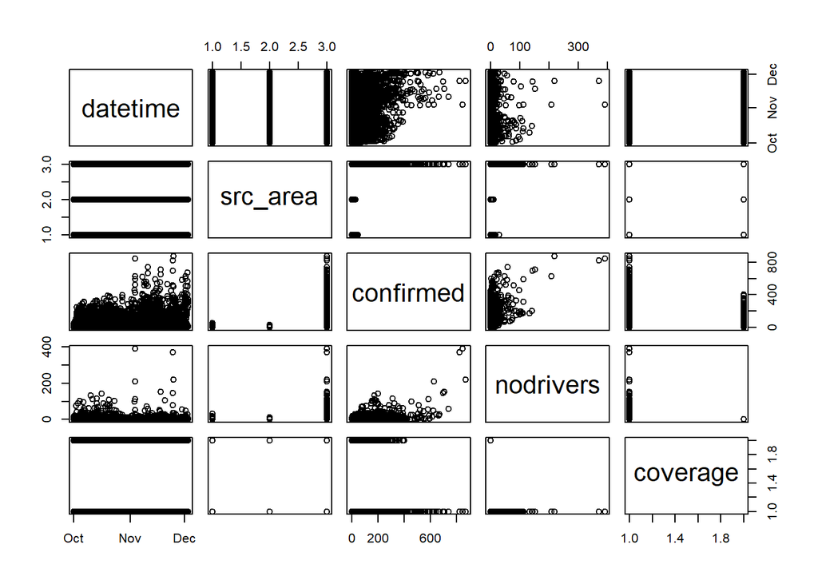

```r
pairs(long_scotty_train[,1:5])
```

### heatmap of time (hour) and weekdays, grouped by area and find the pattern

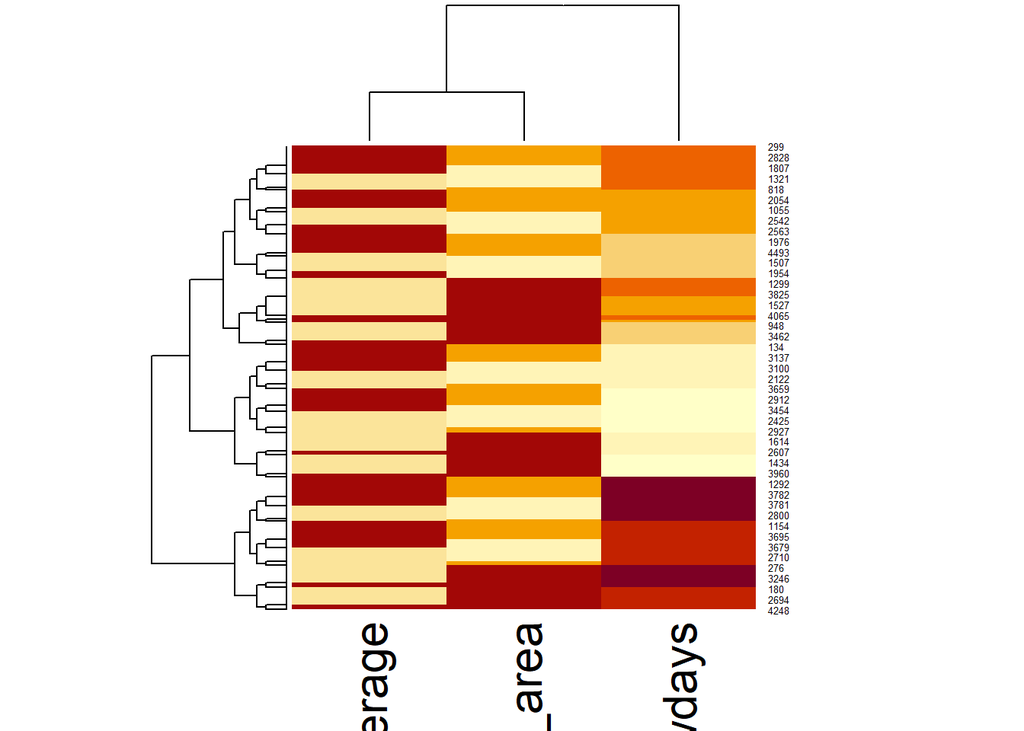

```r
long_scotty_train$wdays <- weekdays(long_scotty_train$datetime)
long_scotty_train <- long_scotty_train %>%
   mutate(wdays = as.factor(wdays))

hm_matrix <- long_scotty_train %>%
   select(src_area, wdays, coverage) %>%
   group_by(src_area)

hm_matrix <- data.matrix(hm_matrix)

heatmap(x = hm_matrix, scale="column")
```

# Model Fitting and Evaluation

## prepare cross-validation data

### proportion of the training vs testing dataset

```r
RNGkind(sample.kind = "Rounding")
set.seed(417)
index <- sample(x = nrow(long_scotty_train), size = 0.8*nrow(long_scotty_train))
data_train <- long_scotty_train[index,]
data_validate <- long_scotty_train[-index, ]
```

## data pre-process and feature engineering

### details of data pre-processing

```r
prop.table(table(data_train$src_area))
```

```
##
##      sxk3      sxk8      sxk9
## 0.3285557 0.3321389 0.3393054
```

### feature engineering/variable selection, including removing unused variable

```r
data_train <- data_train[,-3]
data_train
```

```
## # A tibble: 3,628 x 5
## # Groups:   src_area [3]
##    datetime            src_area nodrivers coverage wdays
##    <dttm>              <fct>        <dbl> <fct>    <fct>
##  1 2017-11-30 12:00:00 sxk8             0 1        Thursday
##  2 2017-10-11 17:00:00 sxk9             5 0        Wednesday
##  3 2017-10-13 12:00:00 sxk8             0 1        Friday
##  4 2017-10-10 16:00:00 sxk3             3 0        Tuesday
##  5 2017-10-06 11:00:00 sxk9             7 0        Friday
##  6 2017-11-24 03:00:00 sxk9             1 0        Friday
##  7 2017-11-06 04:00:00 sxk8             0 1        Monday
##  8 2017-11-02 05:00:00 sxk9             2 0        Thursday
##  9 2017-10-03 04:00:00 sxk3             0 1        Tuesday
## 10 2017-11-15 10:00:00 sxk9             0 1        Wednesday
## # ... with 3,618 more rows
```

### up-sample or down-sample (based on the class proportion)

```r
library(caret)
set.seed(417)
up_train <- upSample(x = data_train[, -ncol(data_train)],
                         y = data_train$src_area)
table(up_train$src_area)
```

```
##
## sxk3 sxk8 sxk9
## 1231 1231 1231
```

```r
set.seed(417)
up_validate <- upSample(x = data_validate[, -ncol(data_validate)],
                         y = data_validate$src_area)
table(up_validate$src_area)
```

```
##
## sxk3 sxk8 sxk9
##  320  320  320
```

```r
set.seed(417)
down_train <- downSample(x = data_train[, -ncol(data_train)],
                         y = data_train$src_area)
table(down_train$src_area)
```

```
##
## sxk3 sxk8 sxk9
## 1192 1192 1192
```

```r
set.seed(417)
down_validate <- downSample(x = data_validate[, -ncol(data_validate)],
                         y = data_validate$src_area)
table(down_validate$src_area)
```

```
##
## sxk3 sxk8 sxk9
##  281  281  281
```

# fitting and evaluation

### model to be used

$$y = bo + bn * xn$$

#### model 1 = up sample with 1 predictor logistic regression

```r
summary(up_train)
```

```
##     datetime                   src_area      nodrivers       coverage
##  Min.   :2017-10-01 00:00:00   sxk3:1231   Min.   :  0.000   0:2015
##  1st Qu.:2017-10-16 17:00:00   sxk8:1231   1st Qu.:  0.000   1:1678
##  Median :2017-11-01 10:00:00   sxk9:1231   Median :  1.000
##  Mean   :2017-11-01 08:58:31               Mean   :  3.354
##  3rd Qu.:2017-11-17 00:00:00               3rd Qu.:  3.000
##  Max.   :2017-12-02 23:00:00               Max.   :392.000
##   Class
##  sxk3:1231
##  sxk8:1231
##  sxk9:1231
##
##
##
```

coverage –> sufficient / insufficient

```r
model_1 <- glm(formula = coverage ~ src_area, family = "binomial", data = up_train)
summary(model_1)
```

```
##
## Call:
## glm(formula = coverage ~ src_area, family = "binomial", data = up_train)
##
## Deviance Residuals:
##     Min       1Q   Median       3Q      Max
## -1.8632  -0.9499  -0.6228   0.6228   1.8632
##
## Coefficients:
##              Estimate Std. Error z value Pr(>|z|)
## (Intercept)  -0.56185    0.05927   -9.48   <2e-16 ***
## src_areasxk8  2.10361    0.09543   22.04   <2e-16 ***
## src_areasxk9 -0.97991    0.09543  -10.27   <2e-16 ***
## ---
## Signif. codes:  0 '***' 0.001 '**' 0.01 '*' 0.05 '.' 0.1 ' ' 1
##
## (Dispersion parameter for binomial family taken to be 1)
##
##     Null deviance: 5088.8  on 3692  degrees of freedom
## Residual deviance: 3906.2  on 3690  degrees of freedom
## AIC: 3912.2
##
## Number of Fisher Scoring iterations: 4
```

```r
library(gtools)
# odds per area ketika sufficient
# --> rasio antara peluang kejadian A dengan peluang kejadian bukan A
exp(model_1$coefficients[[2]])
```

```
## [1] 8.195713
```

```r
exp(model_1$coefficients[[3]])
```

```
## [1] 0.3753447
```

```r
# peluang --> transform log of odds to probability
inv.logit(model_1$coefficients[[2]])
```

```
## [1] 0.8912537
```

```r
inv.logit(model_1$coefficients[[3]])
```

```
## [1] 0.2729096
```

$$log(odds) = -0.56185 + 2.10361 * sxk8 - 0.97991 * sxk9$$

```r
up_train$prob_area <- predict(model_1, up_train,  type = "response")
up_train$predicts_area <- as.factor(ifelse(up_train$prob_area > 0.5,
                                                        "0","1"))

up_validate$prob_area <- predict(model_1, up_validate,  type = "response")
up_validate$predicts_area <- as.factor(ifelse(up_validate$prob_area > 0.5,
                                                        "0","1"))
```

```r
confusionMatrix(as.factor(up_validate$predicts_area),
                up_validate$coverage,
                positive = "1")
```

```
## Confusion Matrix and Statistics
##
##           Reference
## Prediction   0   1
##          0  50 270
##          1 460 180
##
##                Accuracy : 0.2396
##                  95% CI : (0.2129, 0.2679)
##     No Information Rate : 0.5312
##     P-Value [Acc > NIR] : 1
##
##                   Kappa : -0.4898
##
##  Mcnemar's Test P-Value : 2.649e-12
##
##             Sensitivity : 0.40000
##             Specificity : 0.09804
##          Pos Pred Value : 0.28125
##          Neg Pred Value : 0.15625
##              Prevalence : 0.46875
##          Detection Rate : 0.18750
##    Detection Prevalence : 0.66667
##       Balanced Accuracy : 0.24902
##
##        'Positive' Class : 1
##
```

#### model 2 = down sample with 1 predictor

```r
summary(down_train)
```

```
##     datetime                   src_area      nodrivers       coverage
##  Min.   :2017-10-01 00:00:00   sxk3:1192   Min.   :  0.000   0:1950
##  1st Qu.:2017-10-16 21:00:00   sxk8:1192   1st Qu.:  0.000   1:1626
##  Median :2017-11-01 13:30:00   sxk9:1192   Median :  1.000
##  Mean   :2017-11-01 10:22:37               Mean   :  3.341
##  3rd Qu.:2017-11-17 00:00:00               3rd Qu.:  3.000
##  Max.   :2017-12-02 23:00:00               Max.   :392.000
##   Class
##  sxk3:1192
##  sxk8:1192
##  sxk9:1192
##
##
##
```

coverage –> sufficient / insufficient

```r
model_2 <- glm(formula = coverage ~ src_area, family = "binomial", data = down_train)
summary(model_2)
```

```
##
## Call:
## glm(formula = coverage ~ src_area, family = "binomial", data = down_train)
##
## Deviance Residuals:
##     Min       1Q   Median       3Q      Max
## -1.8660  -0.9515  -0.6209   0.6209   1.8660
##
## Coefficients:
##              Estimate Std. Error z value Pr(>|z|)
## (Intercept)  -0.55764    0.06019  -9.264   <2e-16 ***
## src_areasxk8  2.10591    0.09708  21.692   <2e-16 ***
## src_areasxk9 -0.99064    0.09708 -10.204   <2e-16 ***
## ---
## Signif. codes:  0 '***' 0.001 '**' 0.01 '*' 0.05 '.' 0.1 ' ' 1
##
## (Dispersion parameter for binomial family taken to be 1)
##
##     Null deviance: 4928.0  on 3575  degrees of freedom
## Residual deviance: 3776.8  on 3573  degrees of freedom
## AIC: 3782.8
##
## Number of Fisher Scoring iterations: 4
```

```r
library(gtools)
# odds per area ketika sufficient
# --> rasio antara peluang kejadian A dengan peluang kejadian bukan A
exp(model_2$coefficients[[2]])
```

```
## [1] 8.214605
```

```r
exp(model_2$coefficients[[3]])
```

```
## [1] 0.3713404
```

```r
# peluang --> transform log of odds to probability
inv.logit(model_2$coefficients[[2]])
```

```
## [1] 0.8914766
```

```r
inv.logit(model_2$coefficients[[3]])
```

```
## [1] 0.2707865
```

$$log(odds) = -0.55764 + 2.10591 * sxk8 - -0.99064 * sxk9$$

```r
down_train$prob_area <- predict(model_2, down_train,  type = "response")
down_train$predicts_area <- as.factor(ifelse(down_train$prob_area > 0.5,
                                                        "0","1"))

down_validate$prob_area <- predict(model_2, down_validate,  type = "response")
down_validate$predicts_area <- as.factor(ifelse(down_validate$prob_area > 0.5,
                                                        "0","1"))
```

```r
confusionMatrix(as.factor(down_validate$predicts_area),
                down_validate$coverage,
                positive = "1")
```

```
## Confusion Matrix and Statistics
##
##           Reference
## Prediction   0   1
##          0  40 241
##          1 399 163
##
##                Accuracy : 0.2408
##                  95% CI : (0.2123, 0.2711)
##     No Information Rate : 0.5208
##     P-Value [Acc > NIR] : 1
##
##                   Kappa : -0.4977
##
##  Mcnemar's Test P-Value : 5.436e-10
##
##             Sensitivity : 0.40347
##             Specificity : 0.09112
##          Pos Pred Value : 0.29004
##          Neg Pred Value : 0.14235
##              Prevalence : 0.47924
##          Detection Rate : 0.19336
##    Detection Prevalence : 0.66667
##       Balanced Accuracy : 0.24729
##
##        'Positive' Class : 1
##
```

#### model 3 = decision tree up sample

```r
library(partykit)
```

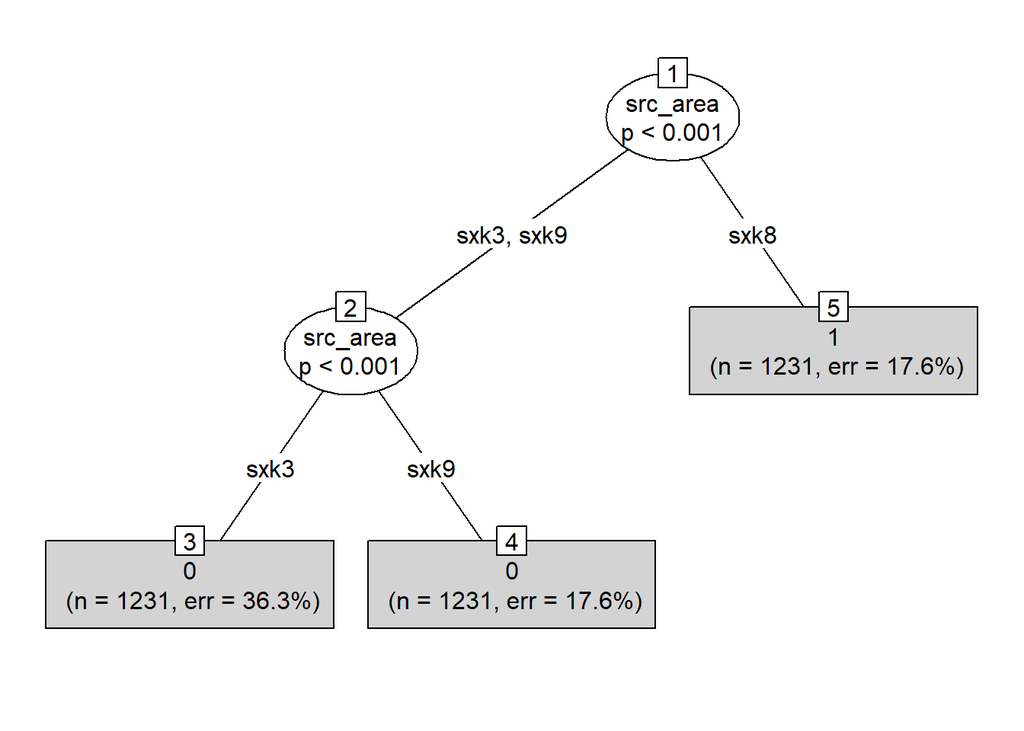

```r
model_3 <- ctree(formula = coverage ~ src_area,
                       data = up_train)

plot(model_3, type = "simple")
```

```r
model_3
```

```
##
## Model formula:
## coverage ~ src_area
##
## Fitted party:
## [1] root
## |   [2] src_area in sxk3, sxk9
## |   |   [3] src_area in sxk3: 0 (n = 1231, err = 36.3%)
## |   |   [4] src_area in sxk9: 0 (n = 1231, err = 17.6%)
## |   [5] src_area in sxk8: 1 (n = 1231, err = 17.6%)
##
## Number of inner nodes:    2
## Number of terminal nodes: 3
```

```r
# prediksi kelas di data test
pred_up_validate <- predict(object = model_3,
                          newdata = up_validate,
                          type = "response")

# confusion matrix data test
confusionMatrix(data = pred_up_validate,
                reference = up_validate$coverage,
                positive = "1")
```

```
## Confusion Matrix and Statistics
##
##           Reference
## Prediction   0   1
##          0 460 180
##          1  50 270
##
##                Accuracy : 0.7604
##                  95% CI : (0.7321, 0.7871)
##     No Information Rate : 0.5312
##     P-Value [Acc > NIR] : < 2.2e-16
##
##                   Kappa : 0.5106
##
##  Mcnemar's Test P-Value : < 2.2e-16
##
##             Sensitivity : 0.6000
##             Specificity : 0.9020
##          Pos Pred Value : 0.8438
##          Neg Pred Value : 0.7188
##              Prevalence : 0.4688
##          Detection Rate : 0.2812
##    Detection Prevalence : 0.3333
##       Balanced Accuracy : 0.7510
##
##        'Positive' Class : 1
##
```

```r
# prediksi kelas di data train
pred_up_train <- predict(object = model_3,
                          newdata = up_train,
                          type = "response")

# confusion matrix data train
confusionMatrix(data = pred_up_train,
                reference = up_train$coverage,
                positive = "1")
```

```
## Confusion Matrix and Statistics
##
##           Reference
## Prediction    0    1
##          0 1798  664
##          1  217 1014
##
##                Accuracy : 0.7614
##                  95% CI : (0.7474, 0.7751)
##     No Information Rate : 0.5456
##     P-Value [Acc > NIR] : < 2.2e-16
##
##                   Kappa : 0.5079
##
##  Mcnemar's Test P-Value : < 2.2e-16
##
##             Sensitivity : 0.6043
##             Specificity : 0.8923
##          Pos Pred Value : 0.8237
##          Neg Pred Value : 0.7303
##              Prevalence : 0.4544
##          Detection Rate : 0.2746
##    Detection Prevalence : 0.3333
##       Balanced Accuracy : 0.7483
##
##        'Positive' Class : 1
##
```

- Recall di data train: 0.6043
- Recall di data test: 0.6000

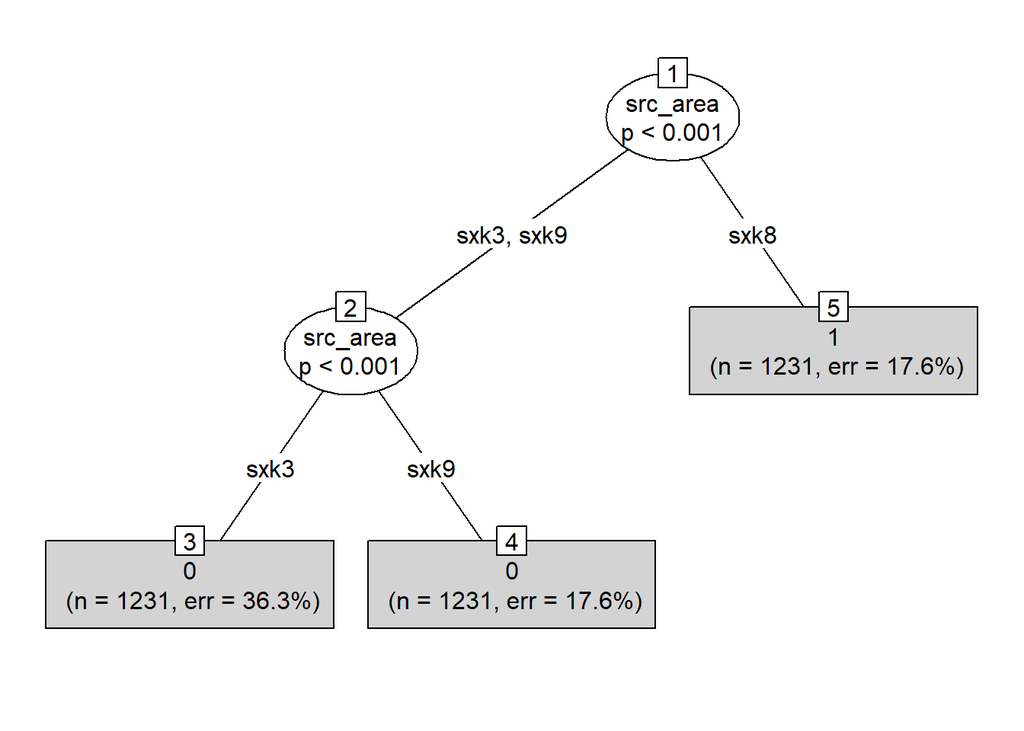

```r
model_3_tuned <- ctree(formula = coverage ~ src_area,
                       data = up_train,
                             control = ctree_control(mincriterion = 0,
                                                     minsplit = 50,
                                                     minbucket = 15))

plot(model_3_tuned, type = "simple")
```

```r
# prediksi kelas di data test
pred_up_validate_tuned <- predict(object = model_3_tuned,
                          newdata = up_validate,
                          type = "response")

# confusion matrix data test
confusionMatrix(data = pred_up_validate_tuned,
                reference = up_validate$coverage,
                positive = "1")
```

```
## Confusion Matrix and Statistics
##
##           Reference
## Prediction   0   1
##          0 460 180
##          1  50 270
##
##                Accuracy : 0.7604
##                  95% CI : (0.7321, 0.7871)
##     No Information Rate : 0.5312
##     P-Value [Acc > NIR] : < 2.2e-16
##
##                   Kappa : 0.5106
##
##  Mcnemar's Test P-Value : < 2.2e-16
##
##             Sensitivity : 0.6000
##             Specificity : 0.9020
##          Pos Pred Value : 0.8438
##          Neg Pred Value : 0.7188
##              Prevalence : 0.4688
##          Detection Rate : 0.2812
##    Detection Prevalence : 0.3333
##       Balanced Accuracy : 0.7510
##
##        'Positive' Class : 1
##
```

```r
# prediksi kelas di data train
pred_up_train_tuned <- predict(object = model_3_tuned,
                          newdata = up_train,
                          type = "response")

# confusion matrix data train
confusionMatrix(data = pred_up_train_tuned,
                reference = up_train$coverage,
                positive = "1")
```

```
## Confusion Matrix and Statistics
##
##           Reference
## Prediction    0    1
##          0 1798  664
##          1  217 1014
##
##                Accuracy : 0.7614
##                  95% CI : (0.7474, 0.7751)
##     No Information Rate : 0.5456
##     P-Value [Acc > NIR] : < 2.2e-16
##
##                   Kappa : 0.5079
##
##  Mcnemar's Test P-Value : < 2.2e-16
##
##             Sensitivity : 0.6043
##             Specificity : 0.8923
##          Pos Pred Value : 0.8237
##          Neg Pred Value : 0.7303
##              Prevalence : 0.4544
##          Detection Rate : 0.2746
##    Detection Prevalence : 0.3333
##       Balanced Accuracy : 0.7483
##
##        'Positive' Class : 1
##
```

- Recall di data train: 0.6043
- Recall di data test: 0.6000

#### model 4 = decision tree down sample

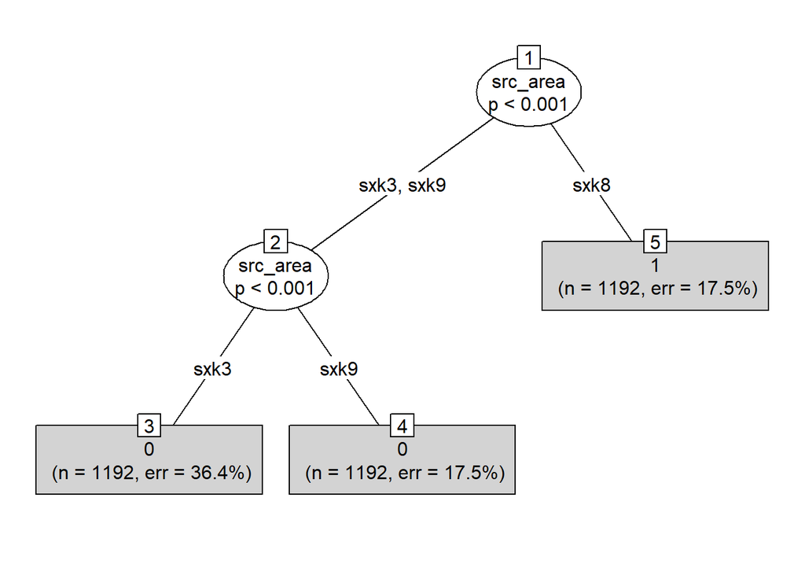

```r
library(partykit)

model_4 <- ctree(formula = coverage ~ src_area,
                       data = down_train)

plot(model_4, type = "simple")
```

```r
model_4
```

```
##
## Model formula:
## coverage ~ src_area
##
## Fitted party:
## [1] root
## |   [2] src_area in sxk3, sxk9
## |   |   [3] src_area in sxk3: 0 (n = 1192, err = 36.4%)
## |   |   [4] src_area in sxk9: 0 (n = 1192, err = 17.5%)
## |   [5] src_area in sxk8: 1 (n = 1192, err = 17.5%)
##
## Number of inner nodes:    2
## Number of terminal nodes: 3
```

```r
# prediksi kelas di data test
pred_down_validate <- predict(object = model_4,
                          newdata = down_validate,
                          type = "response")

# confusion matrix data test
confusionMatrix(data = pred_down_validate,
                reference = down_validate$coverage,
                positive = "1")
```

```
## Confusion Matrix and Statistics
##
##           Reference
## Prediction   0   1
##          0 399 163
##          1  40 241
##
##                Accuracy : 0.7592
##                  95% CI : (0.7289, 0.7877)
##     No Information Rate : 0.5208
##     P-Value [Acc > NIR] : < 2.2e-16
##
##                   Kappa : 0.5116
##
##  Mcnemar's Test P-Value : < 2.2e-16
##
##             Sensitivity : 0.5965
##             Specificity : 0.9089
##          Pos Pred Value : 0.8577
##          Neg Pred Value : 0.7100
##              Prevalence : 0.4792
##          Detection Rate : 0.2859
##    Detection Prevalence : 0.3333
##       Balanced Accuracy : 0.7527
##
##        'Positive' Class : 1
##
```

```r
# prediksi kelas di data train
pred_down_train <- predict(object = model_4,
                          newdata = down_train,
                          type = "response")

# confusion matrix data train
confusionMatrix(data = pred_down_train,
                reference = down_train$coverage,
                positive = "1")
```

```
## Confusion Matrix and Statistics
##
##           Reference
## Prediction    0    1
##          0 1741  643
##          1  209  983
##
##                Accuracy : 0.7617
##                  95% CI : (0.7474, 0.7756)
##     No Information Rate : 0.5453
##     P-Value [Acc > NIR] : < 2.2e-16
##
##                   Kappa : 0.5087
##
##  Mcnemar's Test P-Value : < 2.2e-16
##
##             Sensitivity : 0.6046
##             Specificity : 0.8928
##          Pos Pred Value : 0.8247
##          Neg Pred Value : 0.7303
##              Prevalence : 0.4547
##          Detection Rate : 0.2749
##    Detection Prevalence : 0.3333
##       Balanced Accuracy : 0.7487
##
##        'Positive' Class : 1
##
```

- Recall di data train: 0.6046
- Recall di data test: 0.5965

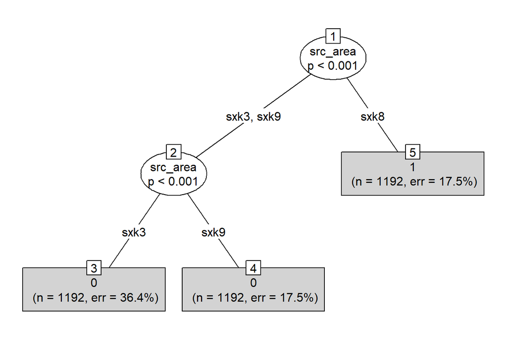

```r
model_4_tuned <- ctree(formula = coverage ~ src_area,
                       data = down_train,
                             control = ctree_control(mincriterion = 0,
                                                     minsplit = 50,
                                                     minbucket = 15))

plot(model_4_tuned, type = "simple")
```

```r
# prediksi kelas di data test
pred_down_validate_tuned <- predict(object = model_4_tuned,
                          newdata = down_validate,
                          type = "response")

# confusion matrix data test
confusionMatrix(data = pred_down_validate_tuned,
                reference = down_validate$coverage,
                positive = "1")
```

```
## Confusion Matrix and Statistics
##
##           Reference
## Prediction   0   1
##          0 399 163
##          1  40 241
##
##                Accuracy : 0.7592
##                  95% CI : (0.7289, 0.7877)
##     No Information Rate : 0.5208
##     P-Value [Acc > NIR] : < 2.2e-16
##
##                   Kappa : 0.5116
##
##  Mcnemar's Test P-Value : < 2.2e-16
##
##             Sensitivity : 0.5965
##             Specificity : 0.9089
##          Pos Pred Value : 0.8577
##          Neg Pred Value : 0.7100
##              Prevalence : 0.4792
##          Detection Rate : 0.2859
##    Detection Prevalence : 0.3333
##       Balanced Accuracy : 0.7527
##
##        'Positive' Class : 1
##
```

```r
# prediksi kelas di data train
pred_down_train_tuned <- predict(object = model_4_tuned,
                          newdata = down_train,
                          type = "response")

# confusion matrix data train
confusionMatrix(data = pred_down_train_tuned,
                reference = down_train$coverage,
                positive = "1")
```

```
## Confusion Matrix and Statistics
##
##           Reference
## Prediction    0    1
##          0 1741  643
##          1  209  983
##
##                Accuracy : 0.7617
##                  95% CI : (0.7474, 0.7756)
##     No Information Rate : 0.5453
##     P-Value [Acc > NIR] : < 2.2e-16
##
##                   Kappa : 0.5087
##
##  Mcnemar's Test P-Value : < 2.2e-16
##
##             Sensitivity : 0.6046
##             Specificity : 0.8928
##          Pos Pred Value : 0.8247
##          Neg Pred Value : 0.7303
##              Prevalence : 0.4547
##          Detection Rate : 0.2749
##    Detection Prevalence : 0.3333
##       Balanced Accuracy : 0.7487
##
##        'Positive' Class : 1
##
```

- Recall di data train: 0.6046
- Recall di data test: 0.5965

```r
set.seed(417)

ctrl <- trainControl(method = "repeatedcv",
                   number = 5, # k-fold
                   repeats = 3) # repetisi

model_5 <- train(coverage ~ src_area,
                 data = up_train,
                 method = "rf", # random forest
                 trControl = ctrl)
saveRDS(model_5, "model_5.RDS") # simpan model
```

```r
# read model
model_5 <- readRDS("model_5.RDS")
model_5
```

```
## Random Forest
##
## 3693 samples
##    1 predictor
##    2 classes: '0', '1'
##
## No pre-processing
## Resampling: Cross-Validated (5 fold, repeated 3 times)
## Summary of sample sizes: 2955, 2955, 2954, 2954, 2954, 2955, ...
## Resampling results:
##
##   Accuracy  Kappa
##   0.761439  0.5078897
##
## Tuning parameter 'mtry' was held constant at a value of 2
```

```r
library(randomForest)
model_5$finalModel
```

```
##
## Call:
##  randomForest(x = x, y = y, mtry = param$mtry)
##                Type of random forest: classification
##                      Number of trees: 500
## No. of variables tried at each split: 2
##
##         OOB estimate of  error rate: 23.86%
## Confusion matrix:
##      0    1 class.error
## 0 1798  217   0.1076923
## 1  664 1014   0.3957092
```

```r
#accuracy model
100 - 23.86
```

```
## [1] 76.14
```

```r
up_validate_pred_cov <- predict(model_5, up_validate, type = "raw")
cm_fb_up <- confusionMatrix(data = up_validate_pred_cov,
                         reference = up_validate$coverage)
cm_fb_up$table
```

```
##           Reference
## Prediction   0   1
##          0 460 180
##          1  50 270
```

```r
varImp(model_5)
```

```
## rf variable importance
##
##              Overall
## src_areasxk8     100
## src_areasxk9       0
```

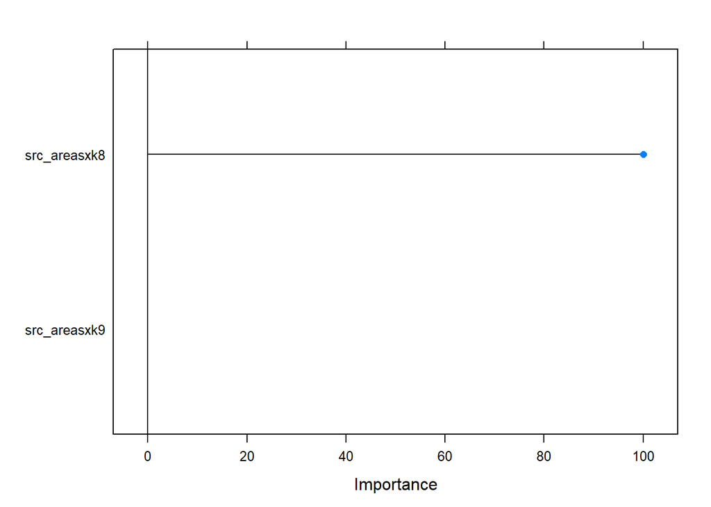

```r
plot(varImp(model_5))
```

#### model 6 = random forest down sample

```r
set.seed(417)

ctrl <- trainControl(method = "repeatedcv",
                   number = 5, # k-fold
                   repeats = 3) # repetisi

model_6 <- train(coverage ~ src_area,
                 data = down_train,
                 method = "rf", # random forest
                 trControl = ctrl)
saveRDS(model_6, "model_6.RDS") # simpan model
```

```r
# read model
model_6 <- readRDS("model_6.RDS")
model_6
```

```
## Random Forest
##
## 3576 samples
##    1 predictor
##    2 classes: '0', '1'
##
## No pre-processing
## Resampling: Cross-Validated (5 fold, repeated 3 times)
## Summary of sample sizes: 2861, 2860, 2861, 2861, 2861, 2861, ...
## Resampling results:
##
##   Accuracy   Kappa
##   0.7617484  0.508617
##
## Tuning parameter 'mtry' was held constant at a value of 2
```

```r
library(randomForest)
model_6$finalModel
```

```
##
## Call:
##  randomForest(x = x, y = y, mtry = param$mtry)
##                Type of random forest: classification
##                      Number of trees: 500
## No. of variables tried at each split: 2
##
##         OOB estimate of  error rate: 23.83%
## Confusion matrix:
##      0   1 class.error
## 0 1741 209   0.1071795
## 1  643 983   0.3954490
```

```r
#accuracy model
100 - 23.83
```

```
## [1] 76.17
```

```r
down_validate_pred_cov <- predict(model_6, down_validate, type = "raw")
cm_fb_down <- confusionMatrix(data = down_validate_pred_cov,
                         reference = down_validate$coverage)
cm_fb_down$table
```

```
##           Reference
## Prediction   0   1
##          0 399 163
##          1  40 241
```

```r
varImp(model_6)
```

```
## rf variable importance
##
##              Overall
## src_areasxk8     100
## src_areasxk9       0
```

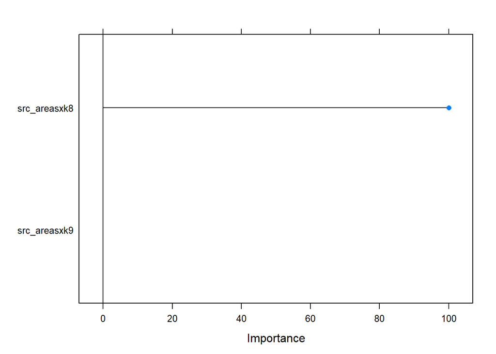

```r
plot(varImp(model_6))
```

## model comparison

```r
read_csv("data/comparison.csv")
```

```
## # A tibble: 6 x 7
##   Model `type sample` method           Accuracy Recall Specifity Precision
##   <dbl> <chr>         <chr>            <chr>    <chr>  <chr>     <chr>
## 1     1 up sample     logistic liniear 23.96%   40.00% 9.80%     28.13%
## 2     2 down sample   logistic liniear 24.08%   40.35% 9.11%     29.00%
## 3     3 up sample     decision tree    76.04%   60.00% 90.20%    84.38%
## 4     4 down sample   decision tree    75.92%   59.65% 90.89%    85.77%
## 5     5 up sample     random forest    76.14%   <NA>   <NA>      <NA>
## 6     6 down sample   random forest    76.17%   <NA>   <NA>      <NA>
```

### accuracy, precision, sensitivity, and specificity. which is important?

Here is the rank of importance from 4 criteria:

```
1. Precision --> focus on true positive
2. Specificity --> don’t want any false positives
3. Accuracy --> false negative and false positive equally costly
4. Recall/ Sensitivity -->  false positives is far better than false negatives
```

With higher precision, the model is also has high confident and better. then we can take a look with specifity value. due to its nature of the case, we need to avoid false positive. We cannot tolerate if the model can predicts the coverage is sufficient while in the reality its insufficient.

### sensitivity-specificity trade-off

There is a trade off between sensitivity and specificity. Its on false positives. Recal/ Sensitivity is more favors false positive and specificity don’t

based on above table and analysis, we can conclude that decision tree with downsample (model 4) is the best model from 6 model.

This model has the highest percentage on precision and specificity

# Prediction Performance

## Validation dataset

- Reached Accuracy > 75% in (your own) validation dataset Yes. 75.92%
- Reached Sensitivity > 85% in (your own) validation dataset No. 59.65%
- Reached Specificity > 70% in (your own) validation dataset Yes. 90.89%
- Reached Precision > 75% in (your own) validation dataset Yes. 85.77%

## test dataset

```r
scotty_test_prep <- down_train %>%
   mutate(datetime = datetime) %>%
   select(src_area, datetime, coverage)

scotty_test_prep
```

```
##      src_area            datetime coverage
## 1        sxk3 2017-10-28 16:00:00        0
## 2        sxk3 2017-10-15 12:00:00        0
## 3        sxk3 2017-10-05 16:00:00        0
## 4        sxk3 2017-11-28 05:00:00        1
## 5        sxk3 2017-10-10 01:00:00        0
## 6        sxk3 2017-11-12 10:00:00        0
## 7        sxk3 2017-10-20 09:00:00        0
## 8        sxk3 2017-11-18 16:00:00        1
## 9        sxk3 2017-10-09 08:00:00        0
## 10       sxk3 2017-10-18 02:00:00        1
## 11       sxk3 2017-11-16 09:00:00        1
## 12       sxk3 2017-11-04 14:00:00        0
## 13       sxk3 2017-11-29 14:00:00        0
## 14       sxk3 2017-10-17 19:00:00        0
```

[output cut: 3562 more lines]

```r
scotty_test %>%
   group_by(src_area) %>%
   pad()
```

```
## pad applied on the interval: hour
```

```
## # A tibble: 504 x 3
## # Groups:   src_area [3]
##    src_area datetime            coverage
##    <chr>    <dttm>              <fct>
##  1 sxk3     2017-12-03 00:00:00 <NA>
##  2 sxk3     2017-12-03 01:00:00 <NA>
##  3 sxk3     2017-12-03 02:00:00 <NA>
##  4 sxk3     2017-12-03 03:00:00 <NA>
##  5 sxk3     2017-12-03 04:00:00 <NA>
##  6 sxk3     2017-12-03 05:00:00 <NA>
##  7 sxk3     2017-12-03 06:00:00 <NA>
##  8 sxk3     2017-12-03 07:00:00 <NA>
##  9 sxk3     2017-12-03 08:00:00 <NA>
## 10 sxk3     2017-12-03 09:00:00 <NA>
## # ... with 494 more rows
```

```r
scotty_test$coverage <- predict(object = model_4_tuned,
                          newdata = scotty_test %>%
                             select(-coverage),
                          type = "response")
scotty_test
```

```
## # A tibble: 504 x 3
##    src_area datetime            coverage
##    <chr>    <dttm>              <fct>
##  1 sxk3     2017-12-03 00:00:00 0
##  2 sxk3     2017-12-03 01:00:00 0
##  3 sxk3     2017-12-03 02:00:00 0
##  4 sxk3     2017-12-03 03:00:00 0
##  5 sxk3     2017-12-03 04:00:00 0
##  6 sxk3     2017-12-03 05:00:00 0
##  7 sxk3     2017-12-03 06:00:00 0
##  8 sxk3     2017-12-03 07:00:00 0
##  9 sxk3     2017-12-03 08:00:00 0
## 10 sxk3     2017-12-03 09:00:00 0
## # ... with 494 more rows
```

```r
# Predict the target using your model
scotty_test$coverage <- predict(object = model_4_tuned,
                          newdata = scotty_test %>%
                             select(-coverage),
                          type = "response")

scotty_test$coverage <- as.factor(ifelse(scotty_test$coverage == 0,
                                                        "insufficient","sufficient"))

# Create submission data
submission <- scotty_test

# save data
write.csv(submission, "submission-nadya.csv", row.names = F)

# check first 3 data
head(submission, 3)
```

```
## # A tibble: 3 x 3
##   src_area datetime            coverage
##   <chr>    <dttm>              <fct>
## 1 sxk3     2017-12-03 00:00:00 insufficient
## 2 sxk3     2017-12-03 01:00:00 insufficient
## 3 sxk3     2017-12-03 02:00:00 insufficient
```

- Reached Accuracy > 75% in test dataset Yes. 79%
- Reached Sensitivity > 85% in test dataset Yes. 91%
- Reached Specificity > 70% in test dataset No. 63%
- Reached Precision > 75% in test dataset Yes. 75%

# Interpretation

### any pre-processing that you need in order to be more interpretable

```r
library(tidymodels)
library(lime)
library(rmarkdown)
#define model spec
model_spec <- rand_forest(
  mode = "classification",
  mtry = 2,
  trees = 500,
  min_n = 1)

#define model engine
model_spec <- set_engine(model_spec,
                         engine = "ranger",
                         seed = 123,
                         num.threads = parallel::detectCores(),
                         importance = "impurity")

#model fitting
set.seed(123)
model <- fit_xy(
  object = model_spec,
  x = select(down_train, -coverage),
  y = select(down_train, coverage))
```

### difference between interpreting black box model with LIME and using an interpretable machine learning model

### explanation fit. signify?

### the most and the least important factors for each observation

# Conclusion

## conclusion of capstone project

### problem can be solved by machine learning?

Yes. machine learning method using Decision Tree for solving classification problem

### model that is used and how is the performance?

Model used is from decision tree method with down sample data. the performance: - on validation dataset: higher in accuracy, specificity and precision than target - on test dataset: higher in accuracy, sensitivity and precision than target

### potential business implementation of your capstone project

With classification problem using decision tree method in this capstone project can be applied in ride-hailing company that ant to define which area that still need growth in the driver number.

The company can implement a bonus package strategy in area on specific time that categorized as Insufficient Area so that a lot driver can be attracted to it. Alternatively, the company need to find a magnet or source of attraction near the area (if its still in the peak hours but still insufficient) and promote this place. other alternatives, the company can build a temporary/permanent base camp for the driver near the area. So that the distance not so large between the insufficient area and not.